# CSPC 440 HW 1 Key

Kyle Payne

January 16, 2016

# 1.

```r
library(knitr)
tort_data <- scan(
text='
1.1
3.1
3.3
3.6
4.3
4.6
4.7
4.7
5.1
5.4
5.6
5.7
6.2
6.4
7.3
7.5
7.7
8.1
8.4
8.9
9.3
11.2
11.8
12.8
')
```

## a. (1 point) By hand, please construct a frequency table with a suitable number of class intervals.

```r
### ---- calculate the rang
r<-max(tort_data) - min(tort_data)
### ---- round the range to an integer value
opt_breaks <- round(r)
factor2 <- factor(cut(tort_data,
                      breaks=opt_breaks))
r_freq_tab <- rbind(table(factor2),table(factor2)/sum(table(factor2)))
row.names(r_freq_tab) <-c("Count", "Relative Frequency")

kable(r_freq_tab)
```

|  | (1.09,2.08] | (3.05,4.03] | (4.03,5] | (5,5.97] | (5.97,6.95] | (6.95,7.93] | (7.93,8.9] | (8.9,9.88] | (10.8,11.8] | (11.8,12.8] |
| --- | --- | --- | --- | --- | --- | --- | --- | --- | --- | --- |
| Count | 1.0000000 | 3.000 | 4.0000000 | 4.0000000 | 2.0000000 | 3.000 | 3.000 | 1.0000000 | 2.0000000 | 1.0000000 |
| Relative Frequency | 0.0416667 | 0.125 | 0.1666667 | 0.1666667 | 0.0833333 | 0.125 | 0.125 | 0.0416667 | 0.0833333 | 0.0416667 |

## b. (0.5 points) By hand, please construct a relative frequency histogram of the data.

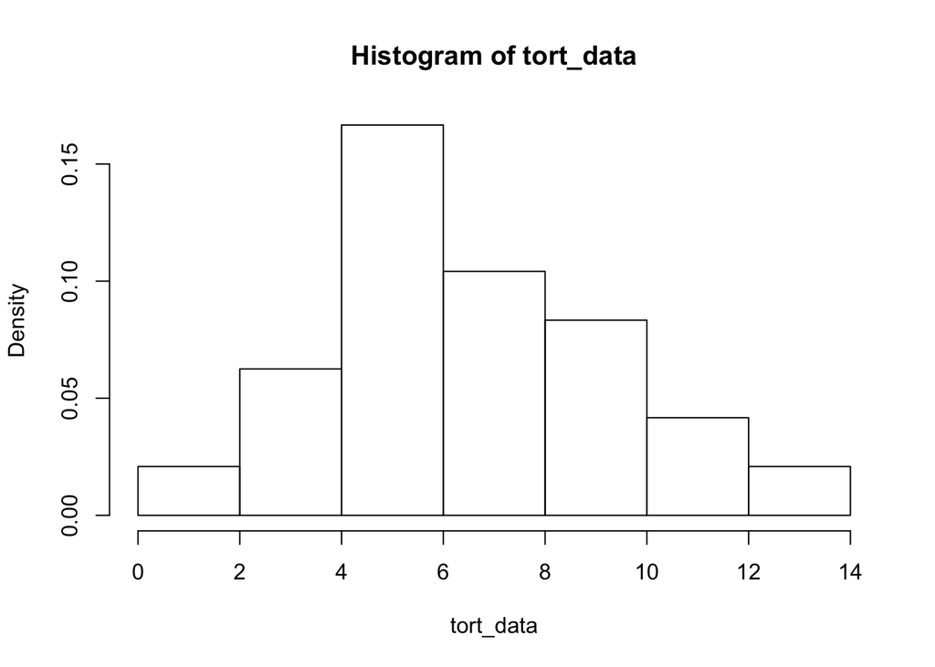

```r
hist(tort_data, freq=F, breaks=7)
```

## c. (1 point) By hand, please construct a stem-and-leaf diagram of these data.

```r
stem(tort_data)
```

```
##
##   The decimal point is 1 digit(s) to the right of the |
##
##   0 | 13344
##   0 | 5555566667888899
##   1 | 123
```

## d. (1 point) By hand, please construct a box plot of these data. Please show all your work including calculations of the mean, Q1, Q2, Q3, the IQR, and upper/lower inner/outer fences. Please round your answers to one decimal place.

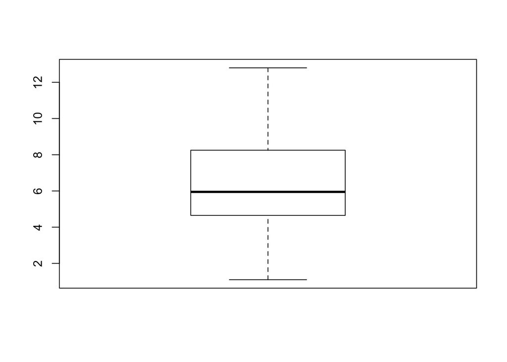

```r
## lower whisker, the lower hinge, the median,
## the upper hinge and the extreme of the upper whisker
bp <- boxplot(tort_data)
```

```r
bp_stats <- t(bp$stats)
colnames(bp_stats) <- c("Lower Whisker", "Lower Hinge",
                        "Median", "Upper Hinge", "Upper Whisker")
row.names(bp_stats) <- c("Values")
kable(bp_stats)
```

|  | Lower Whisker | Lower Hinge | Median | Upper Hinge | Upper Whisker |
| --- | --- | --- | --- | --- | --- |
| Values | 1.1 | 4.65 | 5.95 | 8.25 | 12.8 |

## e. (0.5 points) If you were to randomly select one of these 24 tortillas, what is the probability that the diameter exceeds 11 inches?

```r
mean(tort_data > 11)
```

```
## [1] 0.125
```

## 2. (4 points) Consider the following data on the acceleration (number of seconds from 0-60 mph) of the of the following 40 cars:

```r
accel_data <- scan(
text='
2.05
7.01
8.20
9.65
4.88
7.03
8.35
9.67
4.89
7.03
8.52
9.70
5.11
7.19
8.87
9.79
5.57
7.24
8.95
10.05
5.60
7.29
9.14
10.50
5.62
7.48
9.36
10.68
5.79
7.61
9.51
11.11
6.71
7.62
9.58
11.31
6.90
8.05
9.58
20.01'
)
```

## a. (1 point) By hand, calculate the sample mean, sample median, and sample mode.

```r
ode <- function(x){
  ux <- unique(x)
  ux[which.max(tabulate(match(x, ux)))]
}

ct <- c(mean(accel_data), median(accel_data), ode(accel_data))
names(ct)<-c("mean", "median", "mode")
ct
```

```
##   mean median   mode
##  8.230  8.125  7.030
```

## b. (1 point) By hand, calculate the sample variance and sample standard deviation.

```r
spread <- c(var(accel_data), sd(accel_data))
names(spread) <-c("Variance", "Standard Deviation")
spread
```

```
##           Variance Standard Deviation
##           7.639097           2.763892
```

## c. By hand, construct the intervals

```r
intrvls <- matrix(NA, ncol=2, nrow=3)
for(k in 1:3){
  intrvls[k,] <- mean(accel_data)+c(-1, 1)*k*sd(accel_data)
}

intrvls
```

```
##             [,1]     [,2]
## [1,]  5.46610828 10.99389
## [2,]  2.70221656 13.75778
## [3,] -0.06167516 16.52168
```

## d. (1.5 points) Calculate the percentage of cars falling into each of these three intervals and compare this with the corresponding intervals as predicted by the Empirical Rule. Does this suggest that the distribution of acceleration of these 40 cars follow a “mound-shaped” (i.e., normal) distribution?

```r
for(k in 1:3){
   print(mean(accel_data > intrvls[k,1] & accel_data < intrvls[k,2]))
}
```

```
## [1] 0.825
## [1] 0.95
## [1] 0.975
```

# 3.

## a. (1 point) Describe the difference between a continuous and discrete variable. As part of this, describe how a nominal discrete variable differs from an ordinal discrete variable.

A continuous variable is a random variable that has domain on the real numbers $\mathbb{R}$. Thus, there exists a distance function with continuous variables.

A discrete random variable is a random variable that has domain on the integers, or has a one-to-one correspondence with the integers.

An ordinal random variable is a discrete random variable with ordering, whereas a nominal random variable does not have ordering.

## b.

Sample Mode: Most frequent observation value. Sample Mean: $\frac{1}{n}\sum_{i=1}^{n}X_i$ Sample Median: $\hat{x}_{.5}$, the observation s.t. approximately .5 observations are greater and .5 observations are less than.

The sample mean is the statistic with the greatest influence due to outliers.